# Plot panels/facets/size

`ggplot2` facets allow to split a plot into panels depending on one (or more) categorical variables.  
`ggplot2` themes configure plot graphical settings: colors, fonts, …

➡️Go to [RStudio Cheatsheets/Data Visualization Cheatsheet/Panel Scales](https://rstudio.com/resources/cheatsheets/) to check commands for facets and themes.

## Storing plot in a variable

`ggplot` is a function and it returns an **object (of class `ggplot`)** representing a plot.  
This object can be stored in a variable.  
Notice, that no plot is shown by the following code:

```r
p <- ggplot( pulse ) +
  aes( x = weight, y = height, color = exercise, shape = gender ) +
  geom_point( size = 3, alpha = 0.8 )
```

Only once the variable is printed the plot is shown.

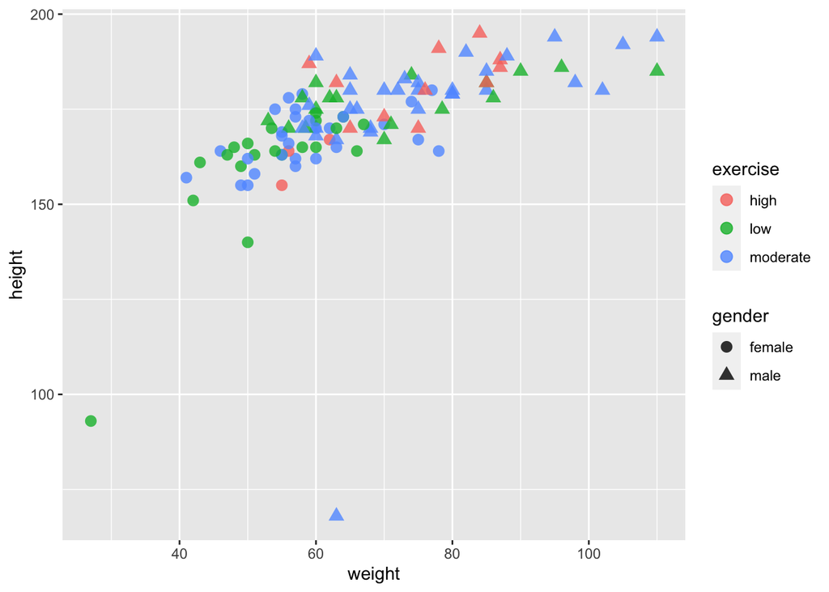

```r
p
```

## Saving plots

Such a plot object may also be **saved to a file** with the `ggsave` function.  
In `Help` you may find how to specify width, height and dpi resolution of the image.  
Multiple file formats are supported and by default they are detrmined from the filename.  
For example, to save plot `p` in PNG format:

```r
ggsave( "my_plot.png", plot = p )
```

## Plot size in R Markdown

It is possible to control the dimensions of the plots in your R Markdown report.  
Try to add additional options to the first line of a chunk which produces a plot.  
Follow this example (the dimensions `fig.width` and `fig.height` are specified in inches and `dpi` sets resolution in pixels per inch):

````
```{r fig.width=3,fig.height=2,dpi=75}
p
```
````

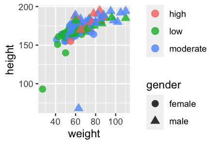

## Facets

Let’s use the plot stored in the variable `p` and combine it with a **facet** command.  
Compare the plot below to the plot above.  
Points corresponding to different levels of `exercise` are shown in separate plot panels.  
Note, that a formula of a form `y_var ~ x_var` is used to specify which variables should define panels in the vertical (`y_var`) and horizontal (`x_var`) directions.  
`.` is used when there should be no panels in a given direction.

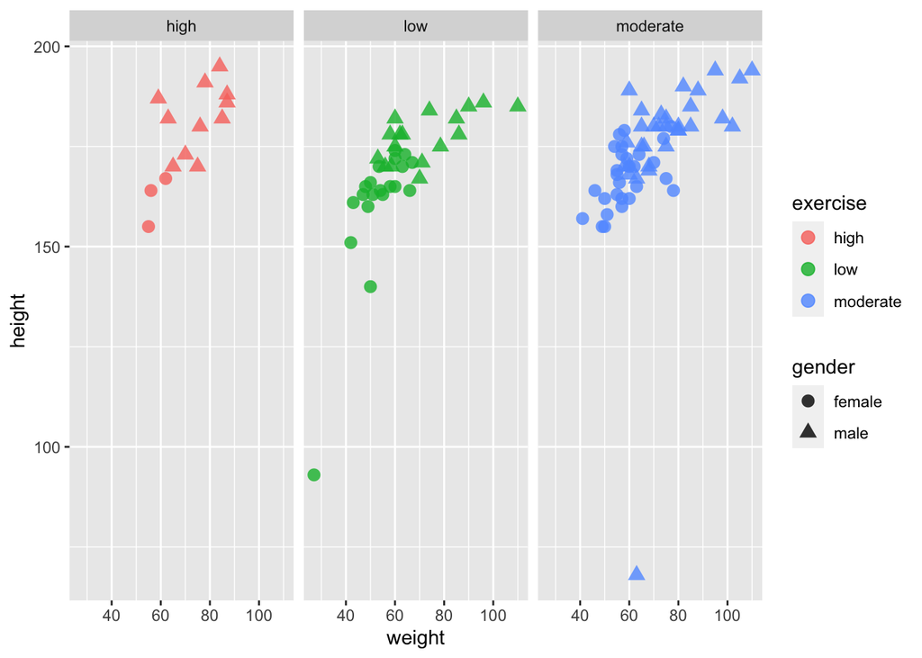

```r
p + facet_grid( . ~ exercise )
```

## Themes

`ggplot2` allows detailed configuration of plots, far beyond the scope of this course.  
We advise to use google search with phrases like [“ggplot2 rotate axis labels”](https://www.google.com/search?q=ggplot+rotate+axis+labels).

Let’s again use the plot stored in the variable `p` and combine it with general **themes**.  
Try each of the following lines and observe the effects:

```r
p + theme_minimal()
p + theme_dark()
p + theme_bw()
```